# Discussion 4 Regex Supplemental Notebook

```python
import re
import pandas as pd
```

```python
class NotStringError(Exception):
    pass

def find_matches(text_list, regex):
    # This function finds the parts of each string in text_list which matches the regex
    if not isinstance(text_list, list):
        text_list = [text_list]

    for i, text in enumerate(text_list):
        if not isinstance(text, str):
             raise NotStringError(f'The {i}th item is not a string.')

    matches = [re.search(regex, text) for text in text_list]

    return [None if match is None else match[0] for match in matches]
```

## Question 1

Which strings contain a match for the following regular expression, "1+1$"?

Remember: "+" matches preceding literal or sub-expression *one* or more times and "$" matches the position at the end of a string.

```python
texts = ['What is 1+1?', 'Make a wish at 11:11', '111 Ways to Succeed']
regex10 = r'1+1$'
find_matches(texts, regex10)
```

```
[None, '11', None]
```

```python
"fas11" " askldfh 1111" "aasdfa111111111"
```

```
'fas11 askldfh 1111aasdfa111111111'
```

## Question 2

Given the text in the cell below,

Which of the following matches exactly to the email addresses (including angle brackets)?

```python
records = [
    '<record> Josh Hug <hug@cs.berkeley.edu> Faculty </record>',
    '<record> Manana Hakobyan <manana.hakobyan@berkeley.eud> TA </record>',
    '<@>'
]
regex5 = r'<.*@.*>'
regex6 = r'<[^<]+@[^>]+>'
regex7 = r'<.*@\w+\..*>'
```

```python
find_matches(records, regex6)
```

```
['<hug@cs.berkeley.edu>', '<manana.hakobyan@berkeley.eud>', None]
```

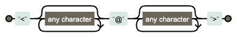

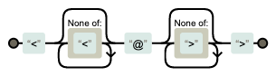

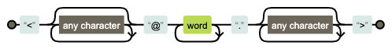

## Question 3

### Skip for now come back, if time review the regex syntax

For each pattern specify the starting and ending position of the first match in the string. The index starts at zero and we are using closed intervals (both endpoints are included).

| . | abcdefg | abcs! | ab abc | abc, 123 |
| --- | --- | --- | --- | --- |
| abc* | [0,2] | . | . | . |
| [^\s]+ | . | . | . | . |
| ab.* c | . | . | . | . |
| [a-z1,9]+ | . | . | . | . |

Note: Try using the https://regex101.com/ tool to understand more about regular expressions!

```python
# Save all of our strings and regex expressions as string objects.
string1 = 'abcdefg'
string2 = 'abcs!'
string3 = 'ab abc'
string4 = 'abc, 123'
regex1 = 'abc*'
regex2 = '[^\s]+'
regex3 = 'ab.*c'
regex4 = '[a-z1,9]+'
```

```python
q3data = [[find_matches(string1,regex1),find_matches(string2,regex1),find_matches(string3,regex1),find_matches(string4,regex1)],
           [find_matches(string1,regex2),find_matches(string2,regex2),find_matches(string3,regex2),find_matches(string4,regex2)],
           [find_matches(string1,regex3),find_matches(string2,regex3),find_matches(string3,regex3),find_matches(string4,regex3)],
           [find_matches(string1,regex4),find_matches(string2,regex4),find_matches(string3,regex4),find_matches(string4,regex4)]]

q3table = pd.DataFrame(q3data, columns = [string1, string2, string3, string4], index = [regex1, regex2, regex3, regex4])

q3table

# Need to query the original strings to get index start and end positions
```

|  | abcdefg | abcs! | ab abc | abc, 123 |
| --- | --- | --- | --- | --- |
| abc* | [abc] | [abc] | [ab] | [abc] |
| [^\s]+ | [abcdefg] | [abcs!] | [ab] | [abc,] |
| ab.*c | [abc] | [abc] | [ab abc] | [abc] |
| [a-z1,9]+ | [abcdefg] | [abcs] | [ab] | [abc,] |

## Question 4

Write a regular expression that matches strings (including the empty strings) that only contain lowercase letters and numbers.

```python
regex11 = '^[^A-Z!]*$'
string6 = ['adsf04RTS!','asdfa342','RA43','adsfa!']
find_matches(string6,regex11)
```

```
[None, 'asdfa342', None, None]
```

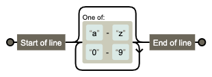

## Question 5

### Come back to after q3

Write a regular expression that matches strings that contain exactly 5 vowels.

Remember:

- `^` matches the position at the beginning of a string (unless used for negation as in "[^]").
- `*` matches the preceding literal or sub-expression zero or more times.
- `[ ]` matches any one of the characters inside of the brackets.
- `{ }` indicates the {minimum, maximum} number of matches.
- `$` matches the position at the end of a string.

```python
regex8 = ''
string5 = ['fabulous', 'berkeley', 'go uc berkeley', 'GO UC Berkeley', 'vowels are fun', 'vowels are great']
find_matches(string5,regex8)
```

```
['', '', '', '', '', '']
```

## Question 6

Given that `address` is a string, use `re.sub` to replace all vowels with a lowercase letter "o". For example "123 Orange Street" would be changed to "123 orango Stroot".

```python
address = "123 Orange Street"
regex12 = r""
re.sub(regex12, "o", address)
```

```
'o1o2o3o oOoroaonogoeo oSotoroeoeoto'
```

## Question 7

Given that `sometext` is a string, use `re.sub` to replace all clusters of non-vowel characters with a single period. For example `a big moon, between us...` would be changed to `a.i.oo.e.ee.u.`.

```python
sometext = "a big moon, between us..."
regex9 = r""
re.sub(regex9, ".", sometext)
```

```
'.a. .b.i.g. .m.o.o.n.,. .b.e.t.w.e.e.n. .u.s.......'
```

## Question 8

Given `sometext = "I've got 10 eggs, 20 gooses, and 30 giants."`, use `re.findall` to extract all the items and quantities from the string. The result should look like `['10 eggs', '20 gooses', '30 giants']`. You may assume that a space separates quantity and type, and that each item ends in s.

```python
sometext = "I've got 10 eggs, 20 gooses, and 30 giants."
regex13 = r""
re.findall(regex13, sometext)
```

[output not shown]

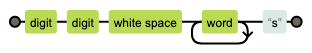

## Question 9

Given the following text in variable `log`:

Fill in the regular expression in the variable `pattern` below so that after it executes, day is 26, month is Jan, and year is 2014.

```python
log = '169.237.46.168 - - [26/Jan/2014:10:47:58 -0800] "GET /stat141/Winter04/ HTTP/1.1" 200 2585 "http://anson.ucdavis.edu/courses/"'
pattern = r""
matches = re.findall(pattern, log)
day, month, year = matches[0]
[day, month, year]
```

[output not shown]

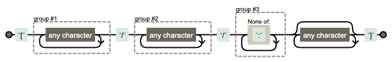